# Modeling the Regulation of the Lac Operon in *E. coli*

Kyle Nguyen, Paul Jacobsen, Ronald Chu, and Camille Anderson

GRÖNSPRÖT

# **Background**

Understanding gene regulatory circuits is crucial to the advancement of the knowledge of the fundamentals of life, developing applications in biotechnology, and facilitating advances in medicine by elucidating disease mechanisms.<sup>1</sup> Gene regulatory circuits are often modeled mathematically with systems of differential equations to gain a better understanding of how complex factors influence gene expression.<sup>1</sup> Modeling a simple gene regulatory circuit, such as the regulation of the *lac* operon in *E. coli*, can aid in the understanding of how more complex gene regulatory circuits function.

The structural genes of the *lac* operon, are involved in the metabolism of lactose and include *lacZ*, which codes for β-galactosidase (an enzyme that breaks lactose into glucose and galactose for further metabolism), *lacY*, which encodes a lactose permease, and *lacA*, which encodes a transacetylase.<sup>2</sup> To conserve resources, the cell does not transcribe these genes at all until lactose is present and does not quickly transcribe these genes while glucose is present.<sup>2</sup> A representation of the *lac* operon in *E. coli* is depicted below.

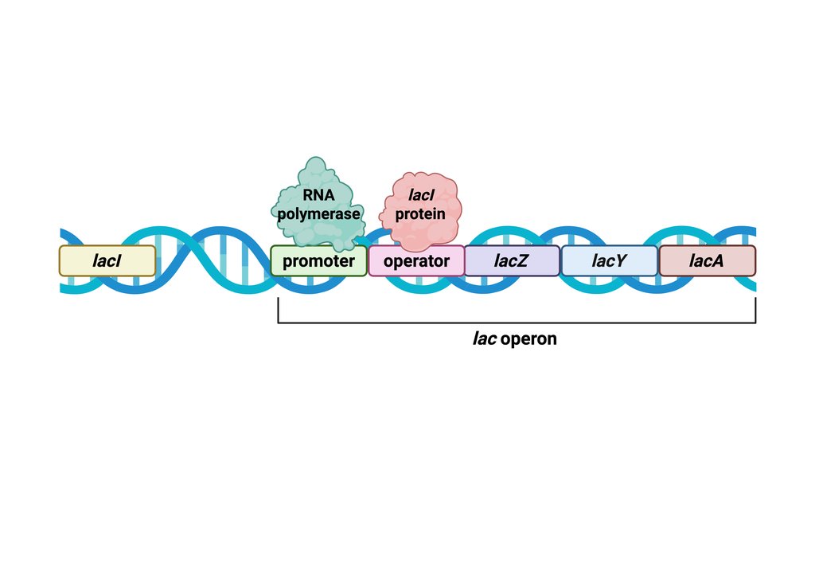

We chose a model of three differential equations from Yildirim et al.<sup>3</sup> This model utilizes delay differential equations, for which the DEs depend on both the previous and the current values of the equation. This is necessary because there are delays associated with the transcription and translation of the *lac* operon.

Our model is made up of the following three quantities:

$$ \begin{align} M(t) &= \mathrm{mRNA} \\ B(t) &= \mathrm{\beta-galactosidase} \\ A(t) &= \mathrm{allolactose} \\ \end{align} $$

The three variable ODE model is as follows:

$$ \begin{align} \frac{d\mathrm{M}}{d\mathrm{t}} &= \alpha_{M}\frac{1 + K_{1}(\mathrm{e}^{-\mu\tau_{M}}A_{\tau_M})^n}{K + K_{1}(\mathrm{e}^{-\mu\tau_{M}}A_{\tau_M})^n} - \tilde{\gamma}_{M} M \tag{1} \\ \frac{d\mathrm{B}}{d\mathrm{t}} &= \alpha_{B} \mathrm{e}^{-\mu \tau_{B}} M_{\tau_B} - \tilde{\gamma}_{B} B \tag{2} \\ \frac{d\mathrm{A}}{d\mathrm{t}} &= \alpha_{A} B \frac{L}{K_{L} + L} - \beta_{A} B \frac{A}{K_{A} + A} - \tilde{\gamma}_{A} A \tag{3} \end{align} $$

Where these are delay differential equations (discrete time delays are due to the transcription and translation processes)

### The biological meanings of each term are as follows:

### For Equation 1 (ODE for mRNA):

**degradation term:**

$\tilde{\gamma}_{M} M = \gamma_{M} M + \mu M$ and represents the loss of mRNA due to degradation and dilution from bacterial growth.

**production term:**

$\tau_M$ is a constant that represents the time delay of mRNA production due to transcription of mRNA from DNA, and must be greater than zero. $A_{\tau M} = A(t-\tau_{M})$

The term $\mathrm{e}^{-\mu\tau_{M}}A_{\tau M}$ represents the concetration of allolactose (A) at time $t-\tau_{M}$ and its dilution due to bacterial growth.

### For Equation 2 (ODE for ß-galactosidase):

**degradation term:**

$\tilde{\gamma}_{B} B = \gamma_{B} B + \mu B$ and represents loss of ß-galactosidase due to degradation and dilution due to bacterial growth.

**production term:**

$\tau_B$ is a constant that represents the time delay of ß-galactosidase production due to tranlastion from mRNA, and must be greater than zero. $M_{\tau_B} = M(t-\tau_{B})$

The production rate of ß-galactosidase should be proportional to the mRNA concentration, accounting for the $M_{\tau_B}$ in the production term.

### For Equation 3 (ODE for allolactose):

**degradation term:**

$\tilde{\gamma}_{A} A = \gamma_{A} A + \mu A$ and represents loss of allolactose due to degradation and dilution due to bacterial growth.

**production term:**

The $\frac{L}{K_{L} + L}$ term models the production of allolactose from the reaction catalyzed by ß-galactosidase to produce allolactose from lactose.

The $\beta_{A} B \frac{A}{K_{A} + A}$ term models the loss of allolactose from the reverse reaction, where ß-galactosidase catalyzes the reaction to form glucose and galactose from allolactose.

### Parameters:

The parameters for the model were determined by Yildirim et al<sup>3</sup> using both experimental data and computational methods, and are depicted in the table below.

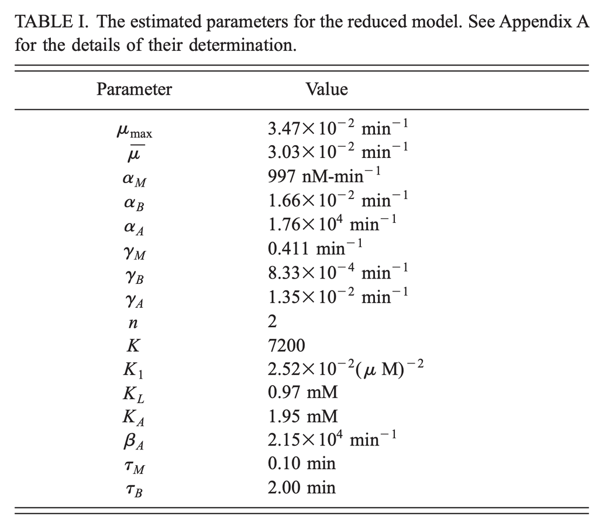

# **Implementation**

The model was integrated using the ddeint library, which is a Scipy-based delay differential equation solver. The code to implement this solver to solve our model is shown below.

```python
# imports
import numpy as np
import matplotlib.pyplot as plt
from ddeint import ddeint
```

```python
# define L
L = 50e-6 # M
```

```python
# define parameters
gamma_m = 0.411 # min^-1
gamma_b = 0.000833 # min^-1
gamma_a = 0.0135 # min^-1
alpha_m = 9.97e-7 # M/min
alpha_b = 0.0166 # min^-1
alpha_a = 17600 # min^-1
n = 2
K = 7200
K1 = 2.52e10
KL = 0.00097 # M
KA = 0.00195 # M
beta_a = 21500 # min^-1
tauM = 0.1 # min
tauB = 2 # min
mu = 0.0303 # min^-1
params = (
    L, gamma_m, gamma_b, gamma_a,
    alpha_m, alpha_b, alpha_a,
    n, K, K1, KL, KA,
    beta_a, tauM, tauB, mu
)
```

```python
# initial conditions
M_0 = 2.3e-10 # M
B_0 = 1.1e-6 # M
A_0 = 1.7e-7 # M
init = [M_0, B_0, A_0]
```

```python
# integration period
ti = 0
tf = 1000
dt = 0.1
```

```python
def model(C, t, L, g_m, g_b, g_a, a_m, a_b, a_a, n, k, k1, kL, kA, b_a, t_M, t_B, mu):
    '''
    models the delayed differential equation for the concentrations of A, B, and M
    '''

    # make everything function of concentration
    M, B, A = C(t)

    # delayed values [M,B,A] also make sure not negative
    A_tauM = max(0,C(t - t_M)[2])
    M_tauB = max(0,C(t - t_B)[0])

    # equations
    dM_dt = a_m * ((1 + (k1 * (np.exp(-mu * t_M) * A_tauM)**n)) /
                   (k + (k1 * (np.exp(-mu * t_M) * A_tauM)**n))) - (g_m * M + mu * M)
    dB_dt = a_b*(np.exp(-mu*t_B))*M_tauB - (g_b*B + mu*B)
    dA_dt = a_a*B*(L/(kL + L)) - b_a*B*(A/(kA + A)) - (g_a*A + mu*A)

    # return results
    return [dM_dt, dB_dt, dA_dt]

def history(t):
    '''
    constant function
    '''
    return init
```

```python
# use ddeint to solve the DDE
t_span = np.arange(ti, tf, dt)
sol = np.maximum(ddeint(model, history, t_span, fargs=params),0)
```

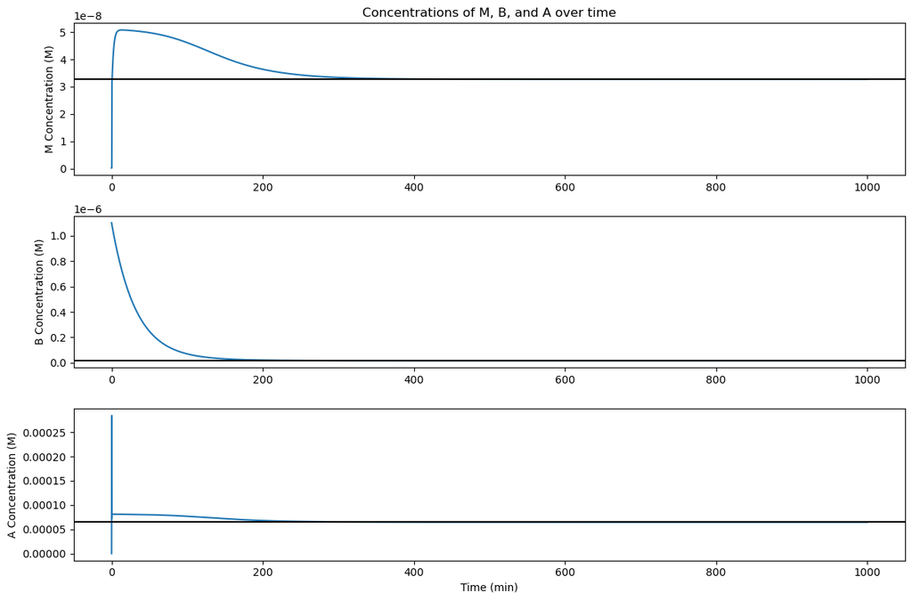

```python
# Set up plot
plt.figure(figsize=(12, 8))

# Plot M
plt.subplot(3, 1, 1)
plt.plot(t_span, sol[:, 0])
plt.title('Concentrations of M, B, and A over time')
plt.ylabel('M Concentration (M)')
plt.axhline(32.71e-9, color = 'k')

# Plot B
plt.subplot(3, 1, 2)
plt.plot(t_span, sol[:, 1])
plt.ylabel('B Concentration (M)')
plt.axhline(16.42e-9, color = 'k')

# Plot A
plt.subplot(3, 1, 3)
plt.plot(t_span, sol[:, 2])
plt.ylabel('A Concentration (M)')
plt.xlabel('Time (min)')
plt.axhline(64.68e-6, color = 'k')

plt.tight_layout()
plt.show()
```

# **Results and Discussion**

The following code was implemented to investigate how convergence of the model might depend on the initial β-galactosidase.

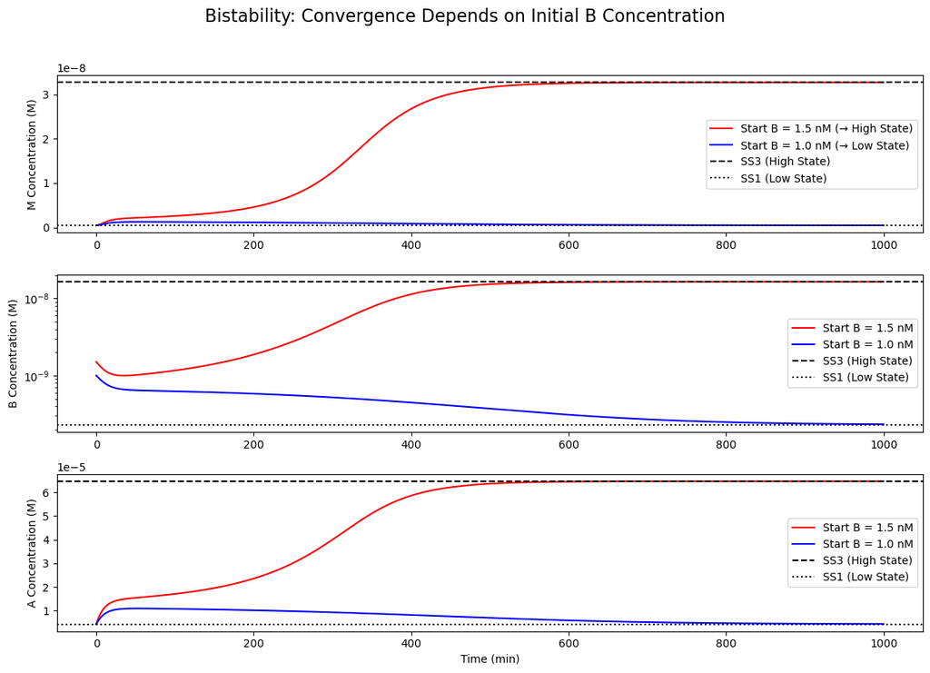

```python
# define L
L = 50e-6 # M

# define parameters
gamma_m = 0.411 # min^-1
gamma_b = 0.000833 # min^-1
gamma_a = 0.0135 # min^-1
alpha_m = 9.97e-7 # M/min
alpha_b = 0.0166 # min^-1
alpha_a = 17600 # min^-1
n = 2
K = 7200
K1 = 2.52e10
KL = 0.00097 # M
KA = 0.00195 # M
beta_a = 21500 # min^-1
tauM = 0.1 # min
tauB = 2 # min
mu = 0.0303 # min^-1
params = (
    L, gamma_m, gamma_b, gamma_a,
    alpha_m, alpha_b, alpha_a,
    n, K, K1, KL, KA,
    beta_a, tauM, tauB, mu
)

# define model
def model(C, t, L, g_m, g_b, g_a, a_m, a_b, a_a, n, K, K1, KL, KA, b_a, t_M, t_B, mu):
    # models the delayed differential equation for the concentrations of A, B, and M

    # make everything function of concentration
    M, B, A = C(t)

    # delayed values [M,B,A] also make sure not negative
    A_tauM = max(0, C(t - t_M)[2])
    M_tauB = max(0, C(t - t_B)[0])

    # equations
    dM_dt = a_m * ((1 + (K1 * (np.exp(-mu * t_M) * A_tauM)**n)) /
                   (K + (K1 * (np.exp(-mu * t_M) * A_tauM)**n))) - (g_m + mu) * M
    dB_dt = a_b*(np.exp(-mu*t_B))*M_tauB - (g_b + mu)*B
    dA_dt = a_a*B*(L/(KL + L)) - b_a*B*(A/(KA + A)) - (g_a + mu)*A

    # return results
    return [dM_dt, dB_dt, dA_dt]

def history(t):
    # constant function
    return init


# integration period
ti = 0
tf = 1000
dt = 0.1
t_span = np.arange(ti, tf, dt)

# Run 1: Converge to SS1 (Low State)
#we start M and A at their SS1 values, but B below the 1.2 nM tipping point [cite: 312, 313]
M_0_low = 0.46e-9  # SS1 M
B_0_low = 1.0e-9   # B < 1.2e-9 threshold
A_0_low = 4.27e-6  # SS1 A
init = [M_0_low, B_0_low, A_0_low] # This global 'init' is used by history()

sol_low = np.maximum(ddeint(model, history, t_span, fargs=params), 0)

#Run 2: Converge to SS3 (High State)
# We start M and A at their SS1 values, but B above the 1.2 nM tipping point [cite: 312, 319]
M_0_high = 0.46e-9  # SS1 M
B_0_high = 1.5e-9   # B > 1.2e-9 threshold
A_0_high = 4.27e-6  # SS1 A
init = [M_0_high, B_0_high, A_0_high] # We re-define the global 'init' for the next run

sol_high = np.maximum(ddeint(model, history, t_span, fargs=params), 0)

# Set up pyplot
plt.figure(figsize=(12, 9))
plt.suptitle('Bistability: Convergence Depends on Initial B Concentration', fontsize=16)

#plot M
plt.subplot(3, 1, 1)
plt.plot(t_span, sol_high[:, 0], color='r', label='Start B = 1.5 nM (→ High State)')
plt.plot(t_span, sol_low[:, 0], color='b', label='Start B = 1.0 nM (→ Low State)')
plt.ylabel('M Concentration (M)')
plt.axhline(32.71e-9, color='k', linestyle='--', label='SS3 (High State)') # SS3 M [cite: 309]
plt.axhline(0.46e-9, color='k', linestyle=':', label='SS1 (Low State)')   # SS1 M [cite: 308]
plt.legend()

#plot B
plt.subplot(3, 1, 2)
plt.plot(t_span, sol_high[:, 1], color='r', label='Start B = 1.5 nM')
plt.plot(t_span, sol_low[:, 1], color='b', label='Start B = 1.0 nM')
plt.ylabel('B Concentration (M)')
plt.axhline(16.42e-9, color='k', linestyle='--', label='SS3 (High State)') # SS3 B [cite: 309]
plt.axhline(0.23e-9, color='k', linestyle=':', label='SS1 (Low State)')   # SS1 B [cite: 308]
#use log scale to match Figure 6 in the paper [cite: 318]
plt.yscale('log')
plt.legend()

#plot A
plt.subplot(3, 1, 3)
plt.plot(t_span, sol_high[:, 2], color='r', label='Start B = 1.5 nM')
plt.plot(t_span, sol_low[:, 2], color='b', label='Start B = 1.0 nM')
plt.ylabel('A Concentration (M)')
plt.xlabel('Time (min)')
plt.axhline(64.68e-6, color='k', linestyle='--', label='SS3 (High State)') # SS3 A [cite: 309]
plt.axhline(4.27e-6, color='k', linestyle=':', label='SS1 (Low State)')   # SS1 A [cite: 308]
plt.legend()

plt.tight_layout(rect=[0, 0.03, 1, 0.96])
plt.show()
```

From these plots, we can see that whether the model converges to the "high" state (*lac* operon gene expression is turned on) or to the "low state" (*lac* operon gene expression is turned off) depends on the initial concentration of β-galactosidase.